# Sang WBM Figure Generation

D. Ford Hannum

5/18/2020

> **FIGURES WILL BE SAVED IN FIGURES/VERSION2/**

# Things to ask

A section of questions that arise when putting together the analysis:

- What are we calling the wildtype and mutant groups?

# Figure 3

Putting together images for Figure 3, which we want to sumarize the single cell RNA-seq (scRNA) between the Mipl (mut) and control samples.

## Figure 3a

UMAP projection of the single cell data. Clusters were labeled using SingleR and marker gene expression, and consolidated into single clusters. The first image is of all the clusters and their labels. The second image is when the clusters are consolidated.

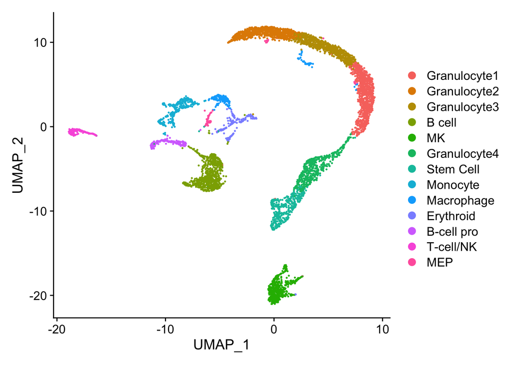

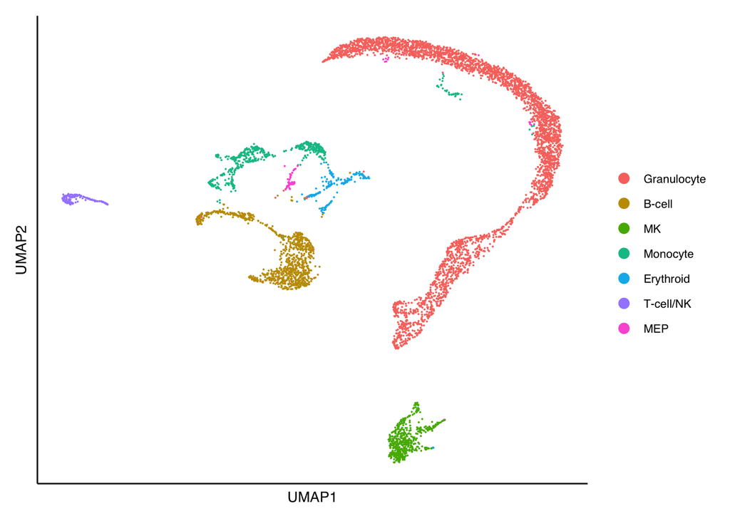

> UMAP projection of the scRNA-seq analysis. Clusters were labeled by cell type and then consolidated into larger clusters based on the cell type

## Figure 3b

Looking at the UMAP projection, but splitting it up between the different experiments.

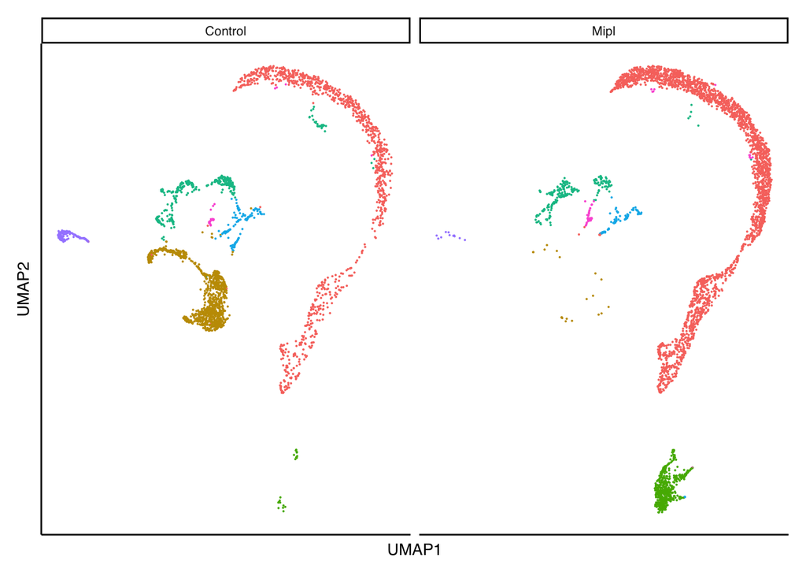

> UMAP projection of the scRNA-seq analysis, split between the two experimental states (Control, Mipl)

## Figure 3c

Heatmap of the distribution of the experiments among the clusters

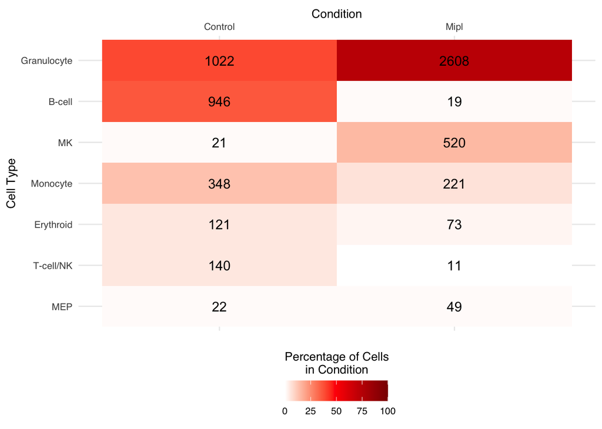

> Cell counts for each cell type among the conditions. Percentage of the cells in each condition accounted for by cell type is represented by red shading

## Figure 3d

Want to show the differential expression of genes within the MK cluster.

```
## Assuming data assay in position 1, with name et is log-transformed.
```

```
##
## Done!
```

```
## Combining coefficients and standard errors
```

```
## Calculating log-fold changes
```

```
## Calculating likelihood ratio tests
```

```
## Refitting on reduced model...
```

```
##
## Done!
```

For the follow-up analysis I’m going to use MAST to determine differentially expressed genes. MAST identifies differentially expressed genes between two groups of cells using a hurdle model tailored to scRNA-seq data. While also stipulating the fold-change in expression greater than 2, we get 123 differentially expressed genes. Previously the wilcoxon test was used, and 93 of the 96 genes from that list were also present in the DE genes from MAST.

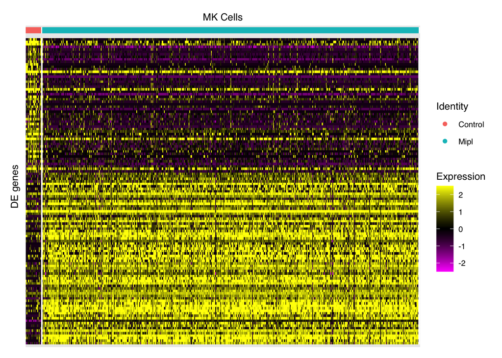

[output not shown]

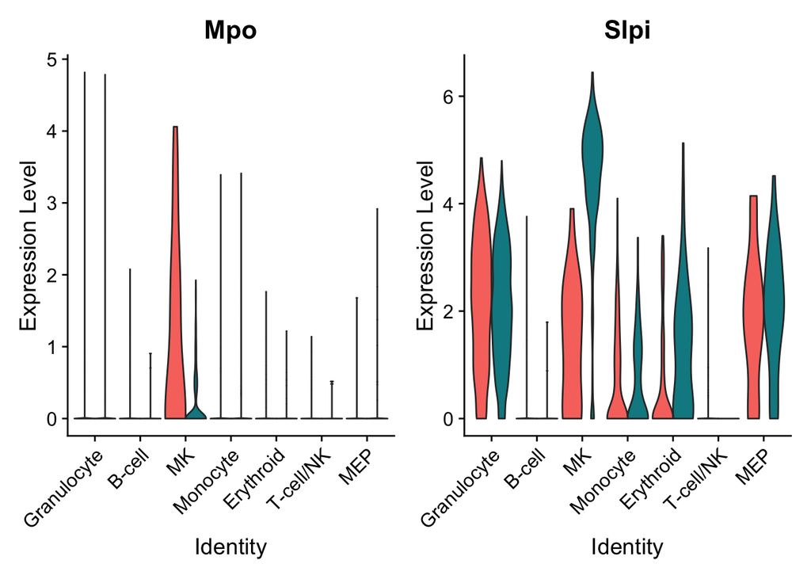

# Profibrotic Factors

I’m starting to generate some potential figures for Fig. 4, which is going to focus on profibrotic factors.

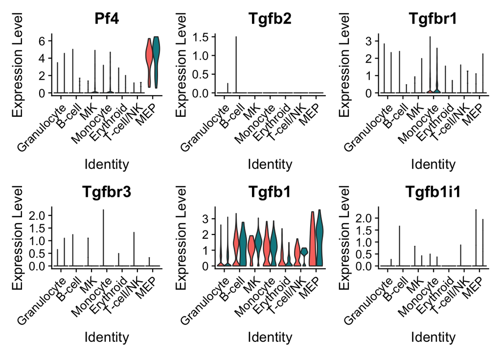

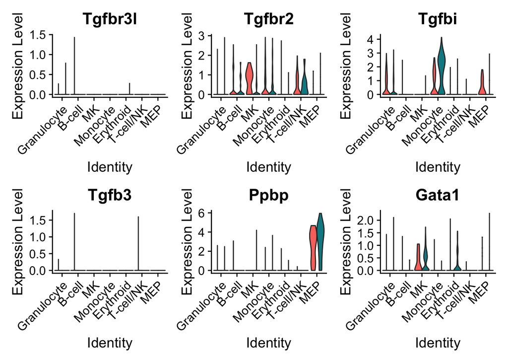

## Follow-Up from Sang Lab

1. Cell clustering: concerning the hematopoietic stem cells (HSCs) and progenitors.
   1. Originally had a progenitor/SC cluster associated with both B-cells and granulocytes but I thought the decision was to merge them into one cluster.
   2. A thought Jun had would be to pull out the granulocyte cluster and do a trajectory analysis just on that cluster. With that method we would be getting at those previously labeled “Stem Cells”
2. Heatmap: wanted to include both the cell number and percentages, also including a bar graph
   1. This can be done. Want to discuss in exactly what kind of format
3. Differential gene expression: want to see what those genes are, in an excel file.
   1. sent a quick unformatted list to Priya yesterday so they had it for your journal club.
   2. when we find a few genes were are excited about/interested in we can label those in particular. I’m thinking adding their name to the y-axis and maybe highlighting their row with a red box.
   3. I added x and y labels

## Other notes from Jun

- this is a standard/common first figure in most single-cell papers
- looking at others was to format the DE heatplot: try changing color schemes, perhaps changes expression levels to (0 to 1)
- adding a GSEA/go term analysis
- adding SingleR heatmap either in the figure or in the supplementary, to show confidence of the labels
- the heatplot is too big and could be 60% of its size, also text size needs to be consistent

## Continued Work

- Visualizing a trajectory analysis in monocle. Want to do this for the entire dataset, and separately for granulocytes, and MK/MEPs/Erythroids
- Read the Oxford paper. Figure out how we differ and what we can compare
- continue working on potential images to use in the profibrotic factor focused Figure 4

## Things that would be helpful for me

- If I could look at a draft of the paper so far, that would be really helpful. I’d have a better understanding of the whole project, and it would help me to write the results section for the sc-analysis.
- Interesting genes from MK DEG list, I could add additional figures for those genes of interest (like what is being done for the profibrotic factors)